# Visualization

Sarah Mixon

4/9/2018

# Legal Status of Same-Sex Marriage, by year

In 2015, the US Supreme Court ruled all state bans on same-sex marriage unconstitutional. This visualization highlights the changes in legal status of same-sex marriages leading up to that ruling, starting in 1995, when Utah became the first state to enact a Defense of Marriage Act. In 2003, Massachusetts became the first state to legalize same-sex marriage following a ruling by the state’s highest court.

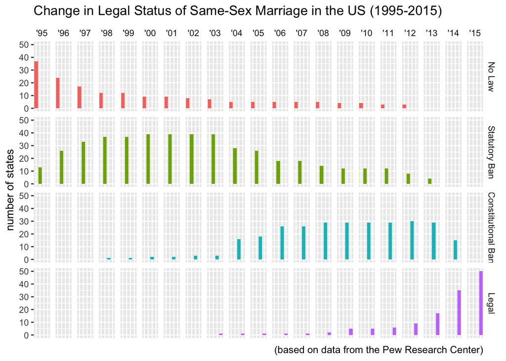

### Defense of Design Decisions

The data is longitudinal, where changes at the observational level may or may not change over time. In this case, some states may only have seen one change, in 2015 when bans on same-sex marriage was ruled unconstitutional by the US Supreme Court. Showing the number of states over time, rather than each individual state, allows the viewer to see the trend at a national level. Representing each law status separately allows the viewer to clearly see trends within and across law status.

The order of the plots was chosen to represent a sense of ranking among the legal statuses. It is important to see how states move from no policy to a state statutory ban to a state constitutional ban before the ruling in 2015.

These decisions help facilitate the understanding of changes in the legal status of same-sex marriage, across states in the years leading up to the US Suprement Court ruling. While some states did legalize same-sex marriage before 2015, a large portion of the states enacted statutory and constitutional bans beginning in 1995.